# DATASCI 151 - Introduction to Statistical Computing II

Lecture 10 - Subsetting Data

Danilo Freire

danilo.freire@emory.edu

Department of Data and Decision Sciences  
Emory University

# I hope you’re all having a great day! 😊

## Today’s lecture

- Today we will dive a little deeper into the `pandas` library
- More specifically, we will learn how to subset data
- This is a very important skill to have when working with data
- We will look into five ways to subset data
  - Using VS Code’s [`Data Wrangler` extension](https://marketplace.visualstudio.com/items?itemName=ms-toolsai.datawrangler)
  - Using `[]`
  - Using `.loc[]`
  - Using `.iloc[]`
  - Using `.query()`
- We will also learn how to sort data with `.sort_values()`

[figure not shown]

## Tip of the day 😉

[figure not shown]

Source: https://www.reddit.com/r/ProgrammerHumor/comments/1tm1n5q/isthatreallythetruth/

## Subsetting data with `Data Wrangler`

- The [`Data Wrangler` extension](https://marketplace.visualstudio.com/items?itemName=ms-toolsai.datawrangler) for VS Code lets you view, filter, sort, and clean data in a table format, with basic statistics built in
- Especially handy when working with an unfamiliar dataset
- Uses a sandboxed environment: changes do not touch the original file unless you save them
- Install: Extensions view (`Ctrl+Shift+X`, `Cmd+Shift+X` on Mac) → search for `Data Wrangler`. [Full documentation](https://code.visualstudio.com/docs/datascience/data-wrangler)

[figure not shown]

- Works on a `.csv` file directly, or on a DataFrame loaded with `pandas` inside a Jupyter notebook

## Subsetting data with `Data Wrangler`

- Quickest way to open it: right-click a `.csv` file → `Open in Data Wrangler`
- Let’s visualise `features.csv` from the `data_raw` folder. The dataset describes cars:
  - `mpg`: miles per gallon (fuel efficiency)
  - `cylinders`: number of cylinders
  - `displacement`: total cylinder volume in the engine
  - `horsepower`: engine power
  - `weight`: weight in pounds
  - `acceleration`: time from 0 to 60 mph
  - `vehicle_id`: unique identifier for each car

[figure not shown]

## Subsetting data with `Data Wrangler`

[figure not shown]

## Subsetting data with `Data Wrangler`

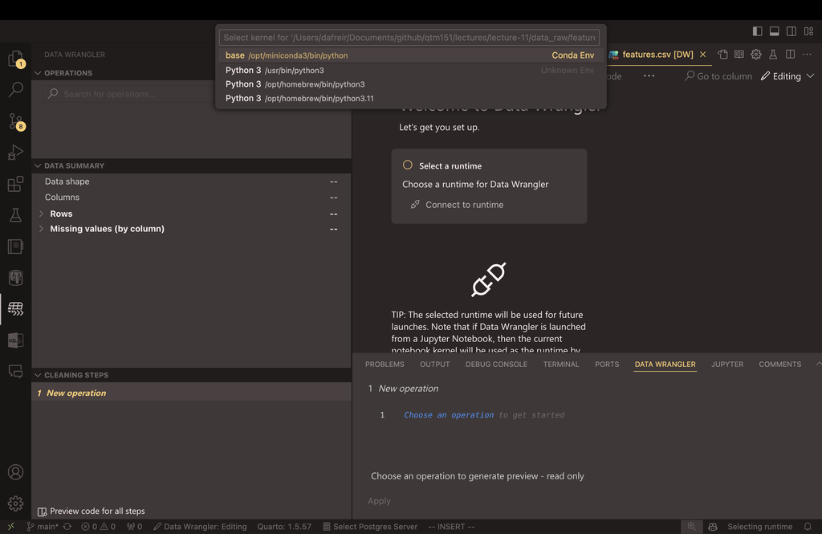

## Subsetting data with `Data Wrangler`

[figure not shown]

# Any questions so far? 🤔

## Subsetting data with `Data Wrangler`

- Click `Filter` to open the filter menu:

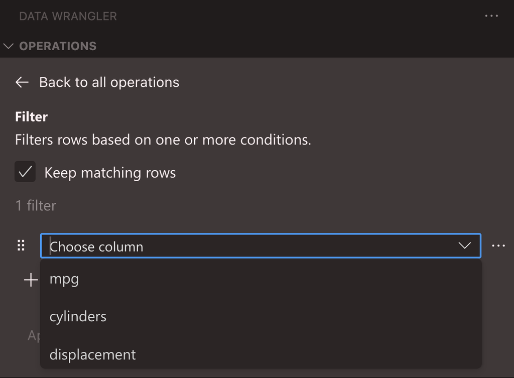

- Pick a column, click `Add Filter`, choose a condition, then `Apply`

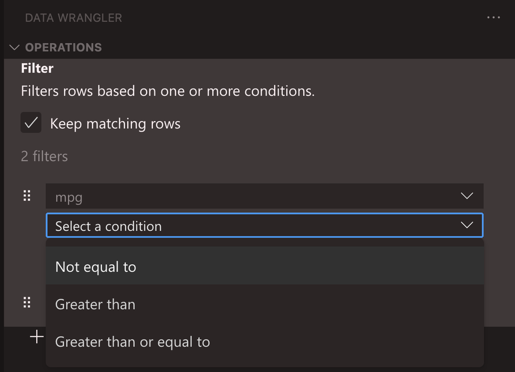

- `Sort` works the same way: click `Sort` and pick the column

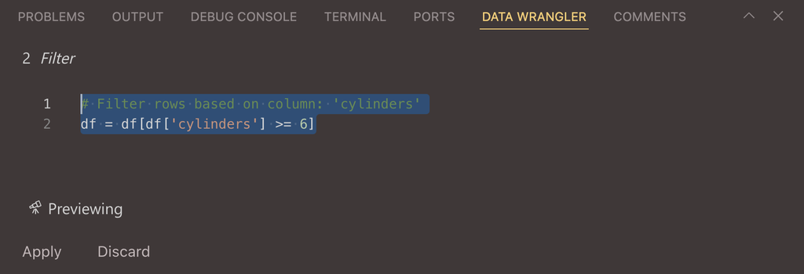

- Best part: `Data Wrangler` shows the equivalent `pandas` code as you click, so it doubles as a pandas tutor 🐼
- From there, use `Export to notebook`, `Export as file`, or `Copy all code` to keep working in Python

## Let’s practise!

Open `features.csv` in `Data Wrangler` and:

- Filter to cars with 6 or more `cylinders`
- Sort by `mpg` in descending order
- Export the code to a Jupyter notebook

[Download the dataset](https://github.com/danilofreire/datasci151-summer/blob/main/lectures/lecture-10/data_raw/features.csv) if you don’t have it (click on `Download Raw File`), then in `Data Wrangler`:

- `Filter` → column `cylinders` → condition `Greater than or equal to` → value `6` → `Apply`

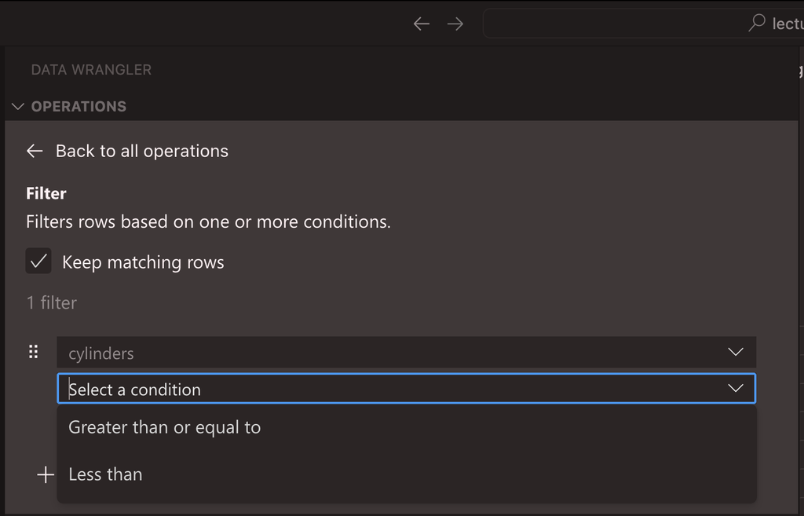

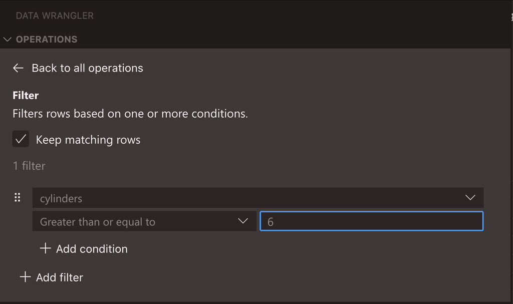

## Try it yourself! 🚗

- Now, let’s add two more conditions to the filter
- We want to find the fastest, least fuel-efficient cars with 6 or more cylinders
- Add a new condition to the filter:
  - Select `acceleration` in `Choose column`
  - Select `Less than or equal to` in `condition`
  - Type `15` in `Value`
- Then, add the second condition:
  - Select `mpg` in `Choose column`
  - Select `Less than or equal to` in `condition`
  - Type `12` in `Value`
  - Click on `Apply`
- How many cars are left? Appendix 01

## Subsetting data with `pandas`

### The `[]` operator

- Now let’s do the same subsetting directly in a Jupyter notebook or a Python script
- The `[]` operator is the most common way to subset data in `pandas`
- Use it to select a column by name: `df['column']`
- Don’t remember the column names? Check them with the `.columns` attribute
- Use the dataset name, then a dot (`.`), then `columns` to list every column
- If you plan to reuse a list of column names, store it in a variable (we’ll do this below)

```python
import pandas as pd
carfeatures = pd.read_csv('data_raw/features.csv')
car_colnames = carfeatures.columns
print(car_colnames)
```

```
Index(['mpg', 'cylinders', 'displacement', 'horsepower', 'weight',
       'acceleration', 'vehicle_id'],
      dtype='str')
```

## Subsetting data with `pandas`

### The `[]` operator

- We can either subset the data by typing the column name or the column index
- With the index (note the brackets):

```python
carfeatures[car_colnames[0]]
```

```
0      18.0
1      15.0
2      18.0
3      16.0
4      17.0
       ...
393    27.0
394    44.0
395    32.0
396    28.0
397    31.0
Name: mpg, Length: 398, dtype: float64
```

- With the name:

```python
carfeatures['mpg']
```

```
0      18.0
1      15.0
2      18.0
3      16.0
4      17.0
       ...
393    27.0
394    44.0
395    32.0
396    28.0
397    31.0
Name: mpg, Length: 398, dtype: float64
```

## Selecting multiple columns

- We can select multiple columns by passing a list of column names
- Let’s say we want to select the columns `mpg` and `weight`
- We can do so by typing:

```python
carfeatures[['mpg', 'weight']]
```

|  | mpg | weight |
| --- | --- | --- |
| 0 | 18.0 | 3504 |
| 1 | 15.0 | 3693 |
| 2 | 18.0 | 3436 |
| 3 | 16.0 | 3433 |
| 4 | 17.0 | 3449 |
| ... | ... | ... |
| 393 | 27.0 | 2790 |
| 394 | 44.0 | 2130 |
| 395 | 32.0 | 2295 |
| 396 | 28.0 | 2625 |
| 397 | 31.0 | 2720 |

398 rows × 2 columns

- We can also store the columns in a variable and pass it to the `[]` operator

```python
list_subsetcols = ["mpg", "weight"]
subcols_carfeatures = carfeatures[list_subsetcols]
subcols_carfeatures
```

|  | mpg | weight |
| --- | --- | --- |
| 0 | 18.0 | 3504 |
| 1 | 15.0 | 3693 |
| 2 | 18.0 | 3436 |
| 3 | 16.0 | 3433 |
| 4 | 17.0 | 3449 |
| ... | ... | ... |
| 393 | 27.0 | 2790 |
| 394 | 44.0 | 2130 |
| 395 | 32.0 | 2295 |
| 396 | 28.0 | 2625 |
| 397 | 31.0 | 2720 |

398 rows × 2 columns

## Subsetting data with `pandas`

- Note that `pandas` uses double brackets when selecting multiple columns
- This is because `pandas` interprets a single bracket as a series (a single column)
- So we need two brackets to pass a list of columns
- An explanation for this behaviour is that `pandas` is trying to avoid ambiguity
- Using `df['col1', 'col2']` would be interpreted as trying to access a single column with the name `'col1', 'col2'`
- Yes, it’s a bizarre name, but it could happen if you, say, merged two columns and named it like that (which is not a good idea!)
- More on this [here](https://www.reddit.com/r/learnpython/comments/yl9htk/pandas_module_double_square_brackets_purpose/) and [here](https://stackoverflow.com/questions/33417991/pandas-why-are-double-brackets-needed-to-select-column-after-boolean-indexing)

## Try it yourself! 🚗

- Load `features.csv` into a DataFrame called `carfeatures` (if you haven’t already)
- Use the `[]` operator to extract the `weight` and `acceleration` columns into a new DataFrame
- Remember: selecting multiple columns needs a list of names inside `[]`, so you’ll end up with two pairs of brackets (`df[[...]]`)
- Display the result. How many rows do you get?
- Appendix 02

## Filtering whole dataframes with `[]`

- We can also use the `[]` operator to filter the whole dataframe, not just the columns
- For example, we can filter the dataframe to show only cars with `mpg` of 25 or more

```python
carfeatures[carfeatures['mpg'] >= 25]
```

|  | mpg | cylinders | displacement | horsepower | weight | acceleration | vehicle_id |
| --- | --- | --- | --- | --- | --- | --- | --- |
| 18 | 27.0 | 4 | 97 | 88 | 2130 | 14.5 | D-1689978 |
| 19 | 26.0 | 4 | 97 | 46 | 1835 | 20.5 | V-1689989 |
| 20 | 25.0 | 4 | 110 | 87 | 2672 | 17.5 | P-1690000 |
| 22 | 25.0 | 4 | 104 | 95 | 2375 | 17.5 | S-1690022 |
| 23 | 26.0 | 4 | 121 | 113 | 2234 | 12.5 | B-1690033 |
| ... | ... | ... | ... | ... | ... | ... | ... |
| 393 | 27.0 | 4 | 140 | 86 | 2790 | 15.6 | F-1694103 |
| 394 | 44.0 | 4 | 97 | 52 | 2130 | 24.6 | V-1694114 |
| 395 | 32.0 | 4 | 135 | 84 | 2295 | 11.6 | D-1694125 |
| 396 | 28.0 | 4 | 120 | 79 | 2625 | 18.6 | F-1694136 |
| 397 | 31.0 | 4 | 119 | 82 | 2720 | 19.4 | C-1694147 |

169 rows × 7 columns

- This will return a new dataframe with only the rows that satisfy the condition
- Note that we are using the `[]` operator twice
- The inner expression `carfeatures['mpg'] >= 25` builds a True/False mask, one value per row
- The outer `[]` then keeps the rows where the mask is `True`

## Filtering whole dataframes with `[]`

- One can make more complex queries by combining multiple conditions

```python
carfeatures[(carfeatures['acceleration']>=10) & (carfeatures['acceleration']<18)]
```

|  | mpg | cylinders | displacement | horsepower | weight | acceleration | vehicle_id |
| --- | --- | --- | --- | --- | --- | --- | --- |
| 0 | 18.0 | 8 | 307 | 130 | 3504 | 12.0 | C-1689780 |
| 1 | 15.0 | 8 | 350 | 165 | 3693 | 11.5 | B-1689791 |
| 2 | 18.0 | 8 | 318 | 150 | 3436 | 11.0 | P-1689802 |
| 3 | 16.0 | 8 | 304 | 150 | 3433 | 12.0 | A-1689813 |
| 4 | 17.0 | 8 | 302 | 140 | 3449 | 10.5 | F-1689824 |
| ... | ... | ... | ... | ... | ... | ... | ... |
| 390 | 32.0 | 4 | 144 | 96 | 2665 | 13.9 | T-1694070 |
| 391 | 36.0 | 4 | 135 | 84 | 2370 | 13.0 | D-1694081 |
| 392 | 27.0 | 4 | 151 | 90 | 2950 | 17.3 | C-1694092 |
| 393 | 27.0 | 4 | 140 | 86 | 2790 | 15.6 | F-1694103 |
| 395 | 32.0 | 4 | 135 | 84 | 2295 | 11.6 | D-1694125 |

315 rows × 7 columns

## Filtering rows and selecting columns

- So far the filter has returned every column for the matching rows
- What if we only care about a few columns?
- We can chain two `[]` operations: first filter the rows, then pick the columns

```python
carfeatures[carfeatures['mpg'] >= 25][['mpg', 'cylinders']]
```

|  | mpg | cylinders |
| --- | --- | --- |
| 18 | 27.0 | 4 |
| 19 | 26.0 | 4 |
| 20 | 25.0 | 4 |
| 22 | 25.0 | 4 |
| 23 | 26.0 | 4 |
| ... | ... | ... |
| 393 | 27.0 | 4 |
| 394 | 44.0 | 4 |
| 395 | 32.0 | 4 |
| 396 | 28.0 | 4 |
| 397 | 31.0 | 4 |

169 rows × 2 columns

- Read it as two steps glued together:
  - `carfeatures[carfeatures['mpg'] >= 25]` keeps the rows with `mpg >= 25`
  - `[['mpg', 'cylinders']]` picks the two columns from that result
- If the line feels crowded, save the filter to a variable first

```python
efficient_cars = carfeatures[carfeatures['mpg'] >= 25]
efficient_cars[['mpg', 'cylinders']]
```

|  | mpg | cylinders |
| --- | --- | --- |
| 18 | 27.0 | 4 |
| 19 | 26.0 | 4 |
| 20 | 25.0 | 4 |
| 22 | 25.0 | 4 |
| 23 | 26.0 | 4 |
| ... | ... | ... |
| 393 | 27.0 | 4 |
| 394 | 44.0 | 4 |
| 395 | 32.0 | 4 |
| 396 | 28.0 | 4 |
| 397 | 31.0 | 4 |

169 rows × 2 columns

## Doing both in one step with `.loc[]`

- The chain works, but `pandas` gives us a cleaner one-liner: `.loc[]`
- Syntax: `df.loc[row_selector, column_selector]`
- The row selector can be a boolean mask (just like with `[]`)
- The column selector is a list of column names

```python
carfeatures.loc[carfeatures['mpg'] >= 25, ['mpg', 'cylinders']]
```

|  | mpg | cylinders |
| --- | --- | --- |
| 18 | 27.0 | 4 |
| 19 | 26.0 | 4 |
| 20 | 25.0 | 4 |
| 22 | 25.0 | 4 |
| 23 | 26.0 | 4 |
| ... | ... | ... |
| 393 | 27.0 | 4 |
| 394 | 44.0 | 4 |
| 395 | 32.0 | 4 |
| 396 | 28.0 | 4 |
| 397 | 31.0 | 4 |

169 rows × 2 columns

- Read it as: “from `carfeatures`, take the rows where `mpg >= 25` and the columns `mpg` and `cylinders`”
- Multiple conditions work the same way as with `[]`

```python
carfeatures.loc[
    (carfeatures['cylinders'] == 8) & (carfeatures['mpg'] <= 15),
    ['mpg', 'cylinders', 'acceleration']
]
```

|  | mpg | cylinders | acceleration |
| --- | --- | --- | --- |
| 1 | 15.0 | 8 | 11.5 |
| 5 | 15.0 | 8 | 10.0 |
| 6 | 14.0 | 8 | 9.0 |
| 7 | 14.0 | 8 | 8.5 |
| 8 | 14.0 | 8 | 10.0 |
| ... | ... | ... | ... |
| 208 | 13.0 | 8 | 13.2 |
| 213 | 13.0 | 8 | 12.0 |
| 214 | 13.0 | 8 | 15.0 |
| 215 | 13.0 | 8 | 14.0 |
| 224 | 15.0 | 8 | 14.9 |

65 rows × 3 columns

- Why is this useful? `.loc[]` puts rows and columns side by side, which mirrors how we think about a table

## Subsetting by row/column position

### The `.iloc[]` (integer location) method

We use `.iloc[]` to select data by row and column position:

- A single row: `df.iloc[0]` (first row)
- Multiple rows: `df.iloc[[0, 1, 2]]` (first three rows)
- Rows and columns together: `df.iloc[[0, 1, 2], [0, 1, 2]]` (first three rows and columns)

The `:` selects all rows or columns, or a range:

- `df.iloc[:, 0]`: all rows, first column
- `df.iloc[:, 0:3]`: all rows, first three columns
- `df.iloc[0:3, 0:3]`: first three rows and columns

Remember: Python is zero-indexed and the last index is not included in lists

## Subsetting by row/column position

### The `.iloc[]` method

- Let’s see some examples!
- We can combine `.iloc[]` with `sort_values(by = 'variable')` to sort the data

```python
carsorted = carfeatures.sort_values(by = "mpg", ascending = False)
print(carsorted.head())
```

```
      mpg  cylinders  displacement horsepower  weight  acceleration vehicle_id
322  46.6          4            86         65    2110          17.9  M-1693322
329  44.6          4            91         67    1850          13.8  H-1693399
325  44.3          4            90         48    2085          21.7  V-1693355
394  44.0          4            97         52    2130          24.6  V-1694114
326  43.4          4            90         48    2335          23.7  V-1693366
```

- For example, to select the first three rows, and then the first three rows and columns:

```python
# Select the first three rows
print(carsorted.iloc[[0, 1, 2]])
```

```
      mpg  cylinders  displacement horsepower  weight  acceleration vehicle_id
322  46.6          4            86         65    2110          17.9  M-1693322
329  44.6          4            91         67    1850          13.8  H-1693399
325  44.3          4            90         48    2085          21.7  V-1693355
```

```python
# Select the first three rows and columns
print(carsorted.iloc[0:3, 0:3])
```

```
      mpg  cylinders  displacement
322  46.6          4            86
329  44.6          4            91
325  44.3          4            90
```

```python
# Compare with the original dataset
print(carfeatures.iloc[0:3, 0:3])
```

```
    mpg  cylinders  displacement
0  18.0          8           307
1  15.0          8           350
2  18.0          8           318
```

## The `.iloc[]` method

- The following command extracts all columns for row zero
- In this first example, we will show the car with the highest `mpg` value

```python
# Select the first row, all columns
display(carsorted.iloc[0,:])
```

```
mpg                  46.6
cylinders               4
displacement           86
horsepower             65
weight               2110
acceleration         17.9
vehicle_id      M-1693322
Name: 322, dtype: object
```

```python
# Select the first three rows, all columns
display(carsorted.iloc[[0,1,2],:])
```

|  | mpg | cylinders | displacement | horsepower | weight | acceleration | vehicle_id |
| --- | --- | --- | --- | --- | --- | --- | --- |
| 322 | 46.6 | 4 | 86 | 65 | 2110 | 17.9 | M-1693322 |
| 329 | 44.6 | 4 | 91 | 67 | 1850 | 13.8 | H-1693399 |
| 325 | 44.3 | 4 | 90 | 48 | 2085 | 21.7 | V-1693355 |

```python
# The `:` can be omitted when selecting all columns
display(carsorted.iloc[[0,1,2]])
```

|  | mpg | cylinders | displacement | horsepower | weight | acceleration | vehicle_id |
| --- | --- | --- | --- | --- | --- | --- | --- |
| 322 | 46.6 | 4 | 86 | 65 | 2110 | 17.9 | M-1693322 |
| 329 | 44.6 | 4 | 91 | 67 | 1850 | 13.8 | H-1693399 |
| 325 | 44.3 | 4 | 90 | 48 | 2085 | 21.7 | V-1693355 |

## Subset blocks of data

```python
# Extract first 5 rows (rows 0 to 4)
display(carfeatures.iloc[0:5,:])
```

|  | mpg | cylinders | displacement | horsepower | weight | acceleration | vehicle_id |
| --- | --- | --- | --- | --- | --- | --- | --- |
| 0 | 18.0 | 8 | 307 | 130 | 3504 | 12.0 | C-1689780 |
| 1 | 15.0 | 8 | 350 | 165 | 3693 | 11.5 | B-1689791 |
| 2 | 18.0 | 8 | 318 | 150 | 3436 | 11.0 | P-1689802 |
| 3 | 16.0 | 8 | 304 | 150 | 3433 | 12.0 | A-1689813 |
| 4 | 17.0 | 8 | 302 | 140 | 3449 | 10.5 | F-1689824 |

```python
# Extract rows 8 onwards
display(carfeatures.iloc[8:,:])
```

|  | mpg | cylinders | displacement | horsepower | weight | acceleration | vehicle_id |
| --- | --- | --- | --- | --- | --- | --- | --- |
| 8 | 14.0 | 8 | 455 | 225 | 4425 | 10.0 | P-1689868 |
| 9 | 15.0 | 8 | 390 | 190 | 3850 | 8.5 | A-1689879 |
| 10 | 15.0 | 8 | 383 | 170 | 3563 | 10.0 | D-1689890 |
| 11 | 14.0 | 8 | 340 | 160 | 3609 | 8.0 | P-1689901 |
| 12 | 15.0 | 8 | 400 | 150 | 3761 | 9.5 | C-1689912 |
| ... | ... | ... | ... | ... | ... | ... | ... |
| 393 | 27.0 | 4 | 140 | 86 | 2790 | 15.6 | F-1694103 |
| 394 | 44.0 | 4 | 97 | 52 | 2130 | 24.6 | V-1694114 |
| 395 | 32.0 | 4 | 135 | 84 | 2295 | 11.6 | D-1694125 |
| 396 | 28.0 | 4 | 120 | 79 | 2625 | 18.6 | F-1694136 |
| 397 | 31.0 | 4 | 119 | 82 | 2720 | 19.4 | C-1694147 |

390 rows × 7 columns

## Try it yourself! 🚗

- Create a new dataset called `car_ascendingmpg` which sorts cars from lowest to highest mpg
- Subset the data of 5 cars with the lowest “mpg”
- Appendix 03

## The `.query()` method

- The `.query()` method is a powerful way to subset data in `pandas`
- It allows you to filter data using a string expression, similar to natural language and SQL
- The syntax is `df.query('expression')`
- The expression is written as if you were writing a sentence
- For example, to filter cars with more than 6 cylinders, we would write:
  - `df.query('cylinders > 6')`
  - `df.query('cylinders > 6 & acceleration < 15 & mpg < 12')`

```python
carfeatures.query("mpg >= 25")
```

|  | mpg | cylinders | displacement | horsepower | weight | acceleration | vehicle_id |
| --- | --- | --- | --- | --- | --- | --- | --- |
| 18 | 27.0 | 4 | 97 | 88 | 2130 | 14.5 | D-1689978 |
| 19 | 26.0 | 4 | 97 | 46 | 1835 | 20.5 | V-1689989 |
| 20 | 25.0 | 4 | 110 | 87 | 2672 | 17.5 | P-1690000 |
| 22 | 25.0 | 4 | 104 | 95 | 2375 | 17.5 | S-1690022 |
| 23 | 26.0 | 4 | 121 | 113 | 2234 | 12.5 | B-1690033 |
| ... | ... | ... | ... | ... | ... | ... | ... |
| 393 | 27.0 | 4 | 140 | 86 | 2790 | 15.6 | F-1694103 |
| 394 | 44.0 | 4 | 97 | 52 | 2130 | 24.6 | V-1694114 |
| 395 | 32.0 | 4 | 135 | 84 | 2295 | 11.6 | D-1694125 |
| 396 | 28.0 | 4 | 120 | 79 | 2625 | 18.6 | F-1694136 |
| 397 | 31.0 | 4 | 119 | 82 | 2720 | 19.4 | C-1694147 |

169 rows × 7 columns

## Let’s see more examples!

- Combine multiple conditions with `and`, `&`, `or`, `|`
- Inside `.query()`, `and` and `&` are equivalent (same for `or` and `|`)
- Outside `.query()`, you must use `&` and `|`, because Python’s `and`/`or` don’t work on pandas Series

```python
carfeatures.query("(acceleration >= 10) and (acceleration < 18)")
```

|  | mpg | cylinders | displacement | horsepower | weight | acceleration | vehicle_id |
| --- | --- | --- | --- | --- | --- | --- | --- |
| 0 | 18.0 | 8 | 307 | 130 | 3504 | 12.0 | C-1689780 |
| 1 | 15.0 | 8 | 350 | 165 | 3693 | 11.5 | B-1689791 |
| 2 | 18.0 | 8 | 318 | 150 | 3436 | 11.0 | P-1689802 |
| 3 | 16.0 | 8 | 304 | 150 | 3433 | 12.0 | A-1689813 |
| 4 | 17.0 | 8 | 302 | 140 | 3449 | 10.5 | F-1689824 |
| ... | ... | ... | ... | ... | ... | ... | ... |
| 390 | 32.0 | 4 | 144 | 96 | 2665 | 13.9 | T-1694070 |
| 391 | 36.0 | 4 | 135 | 84 | 2370 | 13.0 | D-1694081 |
| 392 | 27.0 | 4 | 151 | 90 | 2950 | 17.3 | C-1694092 |
| 393 | 27.0 | 4 | 140 | 86 | 2790 | 15.6 | F-1694103 |
| 395 | 32.0 | 4 | 135 | 84 | 2295 | 11.6 | D-1694125 |

315 rows × 7 columns

## Let’s see more examples!

- Use `.query()` and `sort_values` together

```python
carfeatures.query("(cylinders == 8) & (mpg <= 15) & (acceleration <= 12)").sort_values(by = "mpg")
```

|  | mpg | cylinders | displacement | horsepower | weight | acceleration | vehicle_id |
| --- | --- | --- | --- | --- | --- | --- | --- |
| 124 | 11.0 | 8 | 350 | 180 | 3664 | 11.0 | O-1691144 |
| 67 | 11.0 | 8 | 429 | 208 | 4633 | 11.0 | M-1690517 |
| 95 | 12.0 | 8 | 455 | 225 | 4951 | 11.0 | B-1690825 |
| 90 | 12.0 | 8 | 429 | 198 | 4952 | 11.5 | M-1690770 |
| 42 | 12.0 | 8 | 383 | 180 | 4955 | 11.5 | D-1690242 |
| 43 | 13.0 | 8 | 400 | 170 | 4746 | 12.0 | F-1690253 |
| 96 | 13.0 | 8 | 360 | 175 | 3821 | 11.0 | A-1690836 |
| 94 | 13.0 | 8 | 440 | 215 | 4735 | 11.0 | C-1690814 |
| 91 | 13.0 | 8 | 400 | 150 | 4464 | 12.0 | C-1690781 |
| 62 | 13.0 | 8 | 350 | 165 | 4274 | 12.0 | C-1690462 |
| 44 | 13.0 | 8 | 400 | 175 | 5140 | 12.0 | P-1690264 |
| 166 | 13.0 | 8 | 302 | 129 | 3169 | 12.0 | F-1691606 |
| 213 | 13.0 | 8 | 350 | 145 | 4055 | 12.0 | C-1692123 |
| 38 | 14.0 | 8 | 350 | 165 | 4209 | 12.0 | C-1690198 |
| 13 | 14.0 | 8 | 455 | 225 | 3086 | 10.0 | B-1689923 |
| 63 | 14.0 | 8 | 400 | 175 | 4385 | 12.0 | P-1690473 |
| 11 | 14.0 | 8 | 340 | 160 | 3609 | 8.0 | P-1689901 |
| 86 | 14.0 | 8 | 304 | 150 | 3672 | 11.5 | A-1690726 |
| 8 | 14.0 | 8 | 455 | 225 | 4425 | 10.0 | P-1689868 |
| 7 | 14.0 | 8 | 440 | 215 | 4312 | 8.5 | P-1689857 |
| 6 | 14.0 | 8 | 454 | 220 | 4354 | 9.0 | C-1689846 |
| 39 | 14.0 | 8 | 400 | 175 | 4464 | 11.5 | P-1690209 |
| 12 | 15.0 | 8 | 400 | 150 | 3761 | 9.5 | C-1689912 |
| 10 | 15.0 | 8 | 383 | 170 | 3563 | 10.0 | D-1689890 |
| 9 | 15.0 | 8 | 390 | 190 | 3850 | 8.5 | A-1689879 |
| 121 | 15.0 | 8 | 318 | 150 | 3399 | 11.0 | D-1691111 |
| 5 | 15.0 | 8 | 429 | 198 | 4341 | 10.0 | F-1689835 |
| 1 | 15.0 | 8 | 350 | 165 | 3693 | 11.5 | B-1689791 |

## Let’s see more examples!

- Use `.query()` and select columns
- Note that we are using the `[[]]` operator to select the columns
- Inside `.query()`, both `&` and `and` work; we’ll stick with `&` for consistency, but feel free to mix them as you wish
- Parentheses around each condition are not required, but they help readability

```python
carfeatures.query("(cylinders == 8) & (mpg <= 15) & (acceleration <= 12)")[["mpg", "cylinders", "acceleration"]]
```

|  | mpg | cylinders | acceleration |
| --- | --- | --- | --- |
| 1 | 15.0 | 8 | 11.5 |
| 5 | 15.0 | 8 | 10.0 |
| 6 | 14.0 | 8 | 9.0 |
| 7 | 14.0 | 8 | 8.5 |
| 8 | 14.0 | 8 | 10.0 |
| 9 | 15.0 | 8 | 8.5 |
| 10 | 15.0 | 8 | 10.0 |
| 11 | 14.0 | 8 | 8.0 |
| 12 | 15.0 | 8 | 9.5 |
| 13 | 14.0 | 8 | 10.0 |
| 38 | 14.0 | 8 | 12.0 |
| 39 | 14.0 | 8 | 11.5 |
| 42 | 12.0 | 8 | 11.5 |
| 43 | 13.0 | 8 | 12.0 |
| 44 | 13.0 | 8 | 12.0 |
| 62 | 13.0 | 8 | 12.0 |
| 63 | 14.0 | 8 | 12.0 |
| 67 | 11.0 | 8 | 11.0 |
| 86 | 14.0 | 8 | 11.5 |
| 90 | 12.0 | 8 | 11.5 |
| 91 | 13.0 | 8 | 12.0 |
| 94 | 13.0 | 8 | 11.0 |
| 95 | 12.0 | 8 | 11.0 |
| 96 | 13.0 | 8 | 11.0 |
| 121 | 15.0 | 8 | 11.0 |
| 124 | 11.0 | 8 | 11.0 |
| 166 | 13.0 | 8 | 12.0 |
| 213 | 13.0 | 8 | 12.0 |

## Let’s see more examples!

- Combine `.query()` with global variables

```python
threshold = 25
data_varthreshold_mpg = carfeatures.query("mpg >= @threshold")
data_varthreshold_mpg
```

|  | mpg | cylinders | displacement | horsepower | weight | acceleration | vehicle_id |
| --- | --- | --- | --- | --- | --- | --- | --- |
| 18 | 27.0 | 4 | 97 | 88 | 2130 | 14.5 | D-1689978 |
| 19 | 26.0 | 4 | 97 | 46 | 1835 | 20.5 | V-1689989 |
| 20 | 25.0 | 4 | 110 | 87 | 2672 | 17.5 | P-1690000 |
| 22 | 25.0 | 4 | 104 | 95 | 2375 | 17.5 | S-1690022 |
| 23 | 26.0 | 4 | 121 | 113 | 2234 | 12.5 | B-1690033 |
| ... | ... | ... | ... | ... | ... | ... | ... |
| 393 | 27.0 | 4 | 140 | 86 | 2790 | 15.6 | F-1694103 |
| 394 | 44.0 | 4 | 97 | 52 | 2130 | 24.6 | V-1694114 |
| 395 | 32.0 | 4 | 135 | 84 | 2295 | 11.6 | D-1694125 |
| 396 | 28.0 | 4 | 120 | 79 | 2625 | 18.6 | F-1694136 |
| 397 | 31.0 | 4 | 119 | 82 | 2720 | 19.4 | C-1694147 |

169 rows × 7 columns

## Let’s see more examples!

- Expression with variable names that contain spaces
- Use backticks (`` ` ` ``) to refer to the variable name

```python
carfeatures["new variable"] = carfeatures["mpg"]
data_spacesthreshold_mpg = carfeatures.query("`new variable` >= 25")
data_spacesthreshold_mpg
```

|  | mpg | cylinders | displacement | horsepower | weight | acceleration | vehicle_id | new variable |
| --- | --- | --- | --- | --- | --- | --- | --- | --- |
| 18 | 27.0 | 4 | 97 | 88 | 2130 | 14.5 | D-1689978 | 27.0 |
| 19 | 26.0 | 4 | 97 | 46 | 1835 | 20.5 | V-1689989 | 26.0 |
| 20 | 25.0 | 4 | 110 | 87 | 2672 | 17.5 | P-1690000 | 25.0 |
| 22 | 25.0 | 4 | 104 | 95 | 2375 | 17.5 | S-1690022 | 25.0 |
| 23 | 26.0 | 4 | 121 | 113 | 2234 | 12.5 | B-1690033 | 26.0 |
| ... | ... | ... | ... | ... | ... | ... | ... | ... |
| 393 | 27.0 | 4 | 140 | 86 | 2790 | 15.6 | F-1694103 | 27.0 |
| 394 | 44.0 | 4 | 97 | 52 | 2130 | 24.6 | V-1694114 | 44.0 |
| 395 | 32.0 | 4 | 135 | 84 | 2295 | 11.6 | D-1694125 | 32.0 |
| 396 | 28.0 | 4 | 120 | 79 | 2625 | 18.6 | F-1694136 | 28.0 |
| 397 | 31.0 | 4 | 119 | 82 | 2720 | 19.4 | C-1694147 | 31.0 |

169 rows × 8 columns

## Try it yourself! 🚗

- Subset the data with mpg $\ge$ 25 and cylinders == 8
- Select the columns `mpg` and `cylinders`
- Appendix 04

## Plotting subsets

- `matplotlib` can also be used to plot subsets of data
- The syntax is similar to what we have seen before
- For example, you can just add other `plt.scatter()` or `plt.hist()` commands to the same cell
- Or you can create a `for` loop to plot multiple subsets
- Let’s see an example using `cylinders`
- First, we need to import `matplotlib` and use `pd.unique()` to extract a list with the unique elements in that column

```python
import matplotlib.pyplot as plt

list_unique_cylinders = pd.unique(carfeatures["cylinders"])
print(list_unique_cylinders)
```

```
[8 4 6 3 5]
```

## Plotting subsets

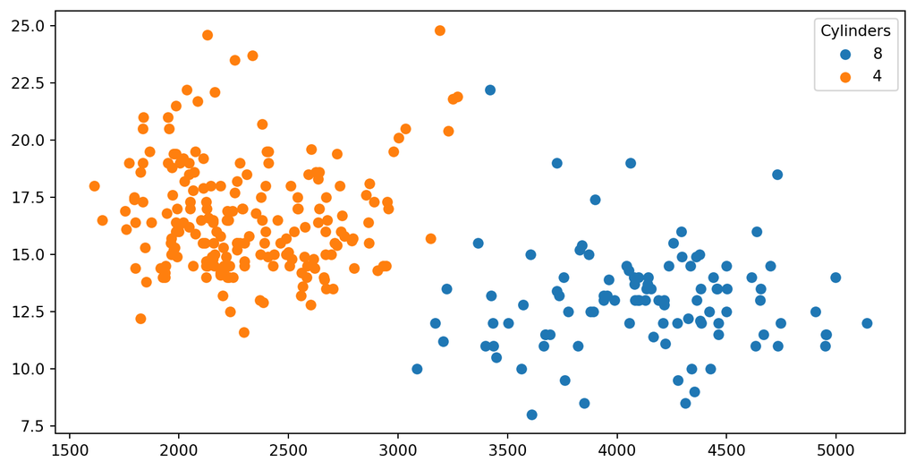

```python
# If we call plt.scatter() twice, it will display both plots on the same graph
# We also include plt.show() at the very end.
df_8 = carfeatures.query("cylinders == 8")
df_4 = carfeatures.query("cylinders == 4")

plt.scatter(x = df_8["weight"],y = df_8["acceleration"])
plt.scatter(x = df_4["weight"],y = df_4["acceleration"])
plt.legend(labels = ["8","4"],
           title  = "Cylinders")

plt.show()

# Note: If we put plt.show() in between the plots, then the results will
# be shown on separate graphs instead.
```

## Plotting subsets

- Using a `for` loop to plot multiple subsets

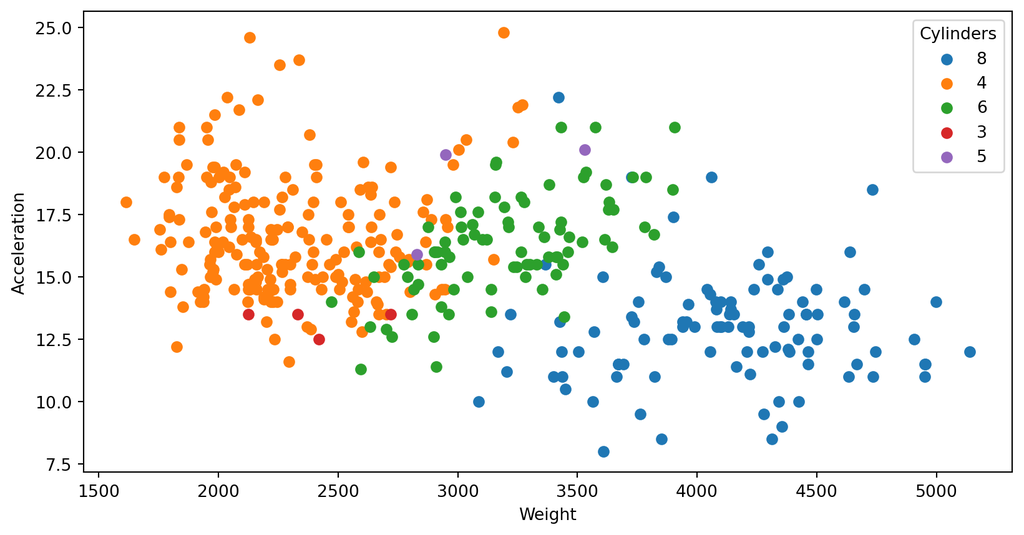

```python
# Compute number of unique categories
list_unique_cylinders = pd.unique(carfeatures["cylinders"])

# Use a for loop to plot a scatter plot between "weight" and "acceleration"
# for each category. Each plot will have a different color

for category in list_unique_cylinders:
    df   = carfeatures.query("cylinders == @category")
    plt.scatter(x = df["weight"],y = df["acceleration"])

# Add labels and a legend
plt.xlabel("Weight")
plt.ylabel("Acceleration")
plt.legend(labels = list_unique_cylinders,
           title  = "Cylinders")
plt.show()
```

## Try it yourself! 🚗

- Compute a histogram of “mpg” by cylinder count
- Make the histograms transparent by adjusting `alpha` in `plt.hist(x = ..., alpha = 0.5)`
- Appendix 05

# And that’s it for today! 🎉

# See you next time! 🚀

## Appendix 01

```python
import pandas as pd
df = pd.read_csv('data_raw/features.csv')
df_filtered = df[(df['cylinders'] >= 6) & (df['acceleration'] <= 15) & (df['mpg'] <= 12)]
print(df_filtered.shape)
df_filtered
```

```
(12, 7)
```

|  | mpg | cylinders | displacement | horsepower | weight | acceleration | vehicle_id |
| --- | --- | --- | --- | --- | --- | --- | --- |
| 25 | 10.0 | 8 | 360 | 215 | 4615 | 14.0 | F-1690055 |
| 26 | 10.0 | 8 | 307 | 200 | 4376 | 15.0 | C-1690066 |
| 27 | 11.0 | 8 | 318 | 210 | 4382 | 13.5 | D-1690077 |
| 42 | 12.0 | 8 | 383 | 180 | 4955 | 11.5 | D-1690242 |
| 67 | 11.0 | 8 | 429 | 208 | 4633 | 11.0 | M-1690517 |
| 69 | 12.0 | 8 | 350 | 160 | 4456 | 13.5 | O-1690539 |
| 90 | 12.0 | 8 | 429 | 198 | 4952 | 11.5 | M-1690770 |
| 95 | 12.0 | 8 | 455 | 225 | 4951 | 11.0 | B-1690825 |
| 103 | 11.0 | 8 | 400 | 150 | 4997 | 14.0 | C-1690913 |
| 104 | 12.0 | 8 | 400 | 167 | 4906 | 12.5 | F-1690924 |
| 106 | 12.0 | 8 | 350 | 180 | 4499 | 12.5 | O-1690946 |
| 124 | 11.0 | 8 | 350 | 180 | 3664 | 11.0 | O-1691144 |

- There are 12 cars left (number of rows)

Back to exercise

## Appendix 02

```python
import pandas as pd
df = pd.read_csv('data_raw/features.csv')
df[['weight', 'acceleration']]
```

|  | weight | acceleration |
| --- | --- | --- |
| 0 | 3504 | 12.0 |
| 1 | 3693 | 11.5 |
| 2 | 3436 | 11.0 |
| 3 | 3433 | 12.0 |
| 4 | 3449 | 10.5 |
| ... | ... | ... |
| 393 | 2790 | 15.6 |
| 394 | 2130 | 24.6 |
| 395 | 2295 | 11.6 |
| 396 | 2625 | 18.6 |
| 397 | 2720 | 19.4 |

398 rows × 2 columns

Back to exercise

## Appendix 03

```python
import pandas as pd
df = pd.read_csv('data_raw/features.csv')
car_ascendingmpg = df.sort_values(by = "mpg")
car_ascendingmpg.iloc[0:5]
```

|  | mpg | cylinders | displacement | horsepower | weight | acceleration | vehicle_id |
| --- | --- | --- | --- | --- | --- | --- | --- |
| 28 | 9.0 | 8 | 304 | 193 | 4732 | 18.5 | H-1690088 |
| 25 | 10.0 | 8 | 360 | 215 | 4615 | 14.0 | F-1690055 |
| 26 | 10.0 | 8 | 307 | 200 | 4376 | 15.0 | C-1690066 |
| 103 | 11.0 | 8 | 400 | 150 | 4997 | 14.0 | C-1690913 |
| 124 | 11.0 | 8 | 350 | 180 | 3664 | 11.0 | O-1691144 |

Back to exercise

## Appendix 04

```python
import pandas as pd
df = pd.read_csv('data_raw/features.csv')
df.query("(mpg >= 25) & (cylinders == 8)")[["mpg", "cylinders"]]
```

|  | mpg | cylinders |
| --- | --- | --- |
| 364 | 26.6 | 8 |

Back to exercise

## Appendix 05

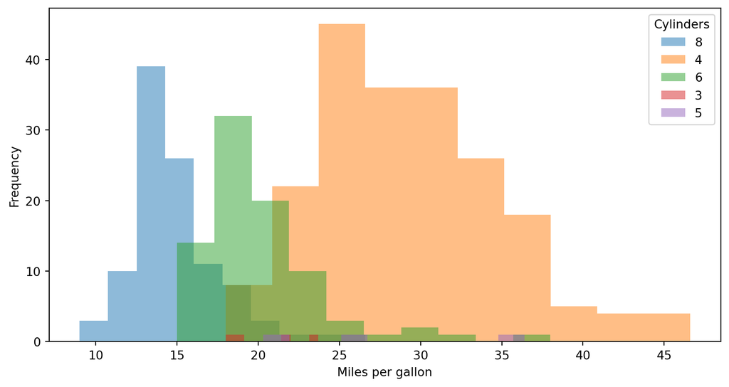

```python
import matplotlib.pyplot as plt
import pandas as pd

df = pd.read_csv('data_raw/features.csv')
list_unique_cylinders = pd.unique(df["cylinders"])

for category in list_unique_cylinders:
    df_category = df.query("cylinders == @category")
    plt.hist(x = df_category["mpg"], alpha = 0.5, bins = 10)

plt.xlabel("Miles per gallon")
plt.ylabel("Frequency")

plt.legend(labels = list_unique_cylinders,
           title  = "Cylinders")
plt.show()
```

Back to exercise